# Assignment 13

Cheryl Bowersox

Saturday, May 02, 2015

## compute the derivitave using limits

$f(x) = x^3 + x^2$

```r
fofx <- function(a){
  f <- a^2 +a^3
  return(f)
}
limatx <- function(x){
  lim <- c()
  small.h <- c()
  h <- .1
  # limit of f as h--> 0
  while (h > .000000001){
    lim <- c((fofx(x+h)-fofx(x))/h, lim, (fofx(x-h)-fofx(x))/-h) # 0 from right
    small.h <- c(h, small.h, -h)  #
    h <- h/5
  }
  r <- data.frame(small.h, lim)
  return(r)
}
```

The result of computing $\lim_{x\to0}\frac{f(x-h) - f(x)}{h}$ for a given x and very small values of h approaching 0 converges to a single value as h gets closer to 0. The value of that convergence is the derivative f at x, this can be demonstrated both numerically and graphically

An example where x = 2 gives the following results as h approaches 0

```r
x <- 2
vals <- limatx(x)
df <- round(vals[1,2],6)
```

Numerically the mean and median of the resulting values converge to a single value as h approaches 0 from right and left

```r
summary(vals)
```

```
##     small.h               lim
##  Min.   :-1.00e-01   Min.   :15.31
##  1st Qu.:-1.28e-05   1st Qu.:16.00
##  Median : 0.00e+00   Median :16.00
##  Mean   : 0.00e+00   Mean   :16.00
##  3rd Qu.: 1.28e-05   3rd Qu.:16.00
##  Max.   : 1.00e-01   Max.   :16.71
```

Resulting values for small positive h are:

```r
head(vals,5)
```

```
##     small.h      lim
## 1 2.048e-09 16.00000
## 2 1.024e-08 16.00000
## 3 5.120e-08 16.00000
## 4 2.560e-07 16.00000
## 5 1.280e-06 16.00001
```

Resulting values for small negative h are:

```r
tail(vals,5)
```

```
##       small.h      lim
## 20 -1.280e-06 15.99999
## 21 -2.560e-07 16.00000
## 22 -5.120e-08 16.00000
## 23 -1.024e-08 16.00000
## 24 -2.048e-09 16.00000
```

The resulting graph of the values demonstrates the convergence at 16

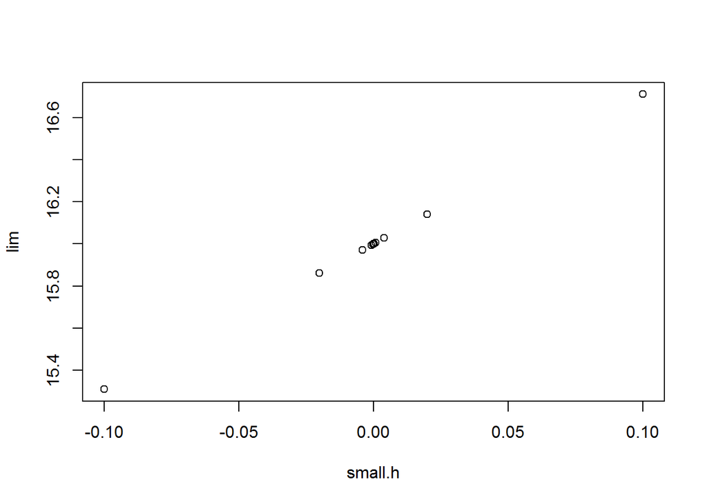

The derivative f’(x) where x = 2 is 16

Example for x = 4.2:

Summary of results

```r
summary(limatx(4.2))
```

```
##     small.h               lim
##  Min.   :-1.00e-01   Min.   :59.97
##  1st Qu.:-1.28e-05   1st Qu.:61.32
##  Median : 0.00e+00   Median :61.32
##  Mean   : 0.00e+00   Mean   :61.32
##  3rd Qu.: 1.28e-05   3rd Qu.:61.32
##  Max.   : 1.00e-01   Max.   :62.69
```

Plot of results

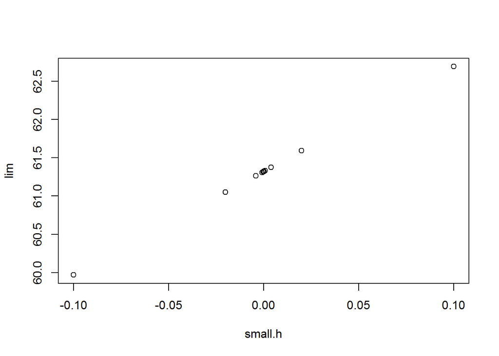

The derivative f’(x) where x = 4.2 is 61.320005

## compute the area under the curve for x = [1,3]

$f(x) = 3x^2 + 4x$

```r
fofx2 <- function(a){
  f <- 3 * a^2 + 4 * a
  return(f)
}
limatx2 <- function(a,b,dx){  #where a is begining of interval, dx is interval
  int <- b - a #size of total interval
  lim <- 0
  x <- a
  if(dx < int){
    while ( x < b){
      lim <- fofx2(x + dx) * dx + lim
      x <- x + dx
    }
  }
 return(lim)
}
v <- c(1:6)
deltax <- 1/10^v

i = 1
result <- c()

while(i < 7){
  result <- c(result,limatx2(1,3,deltax[i]))
  i<- i +1
}
conv <- round(result[6],0)
dfint <- data.frame(deltax,result)
```

For very small intervals the area under f(x) converges to 42

```r
dfint
```

```
##   deltax   result
## 1  1e-01 43.61000
## 2  1e-02 42.55230
## 3  1e-03 42.05502
## 4  1e-04 42.00160
## 5  1e-05 42.00016
## 6  1e-06 42.00002
```

Plotting the interval and the resulting value gives:

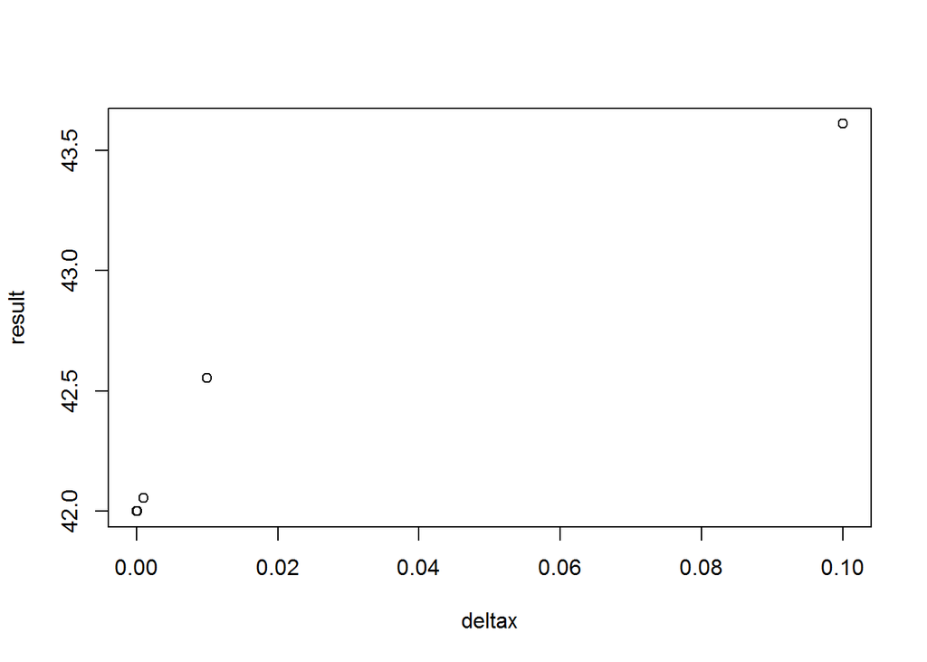

## Solving through analysis

### Integration by parts

$F = \int\sin(x)\cos(x)\,dx\\ f(x) = \sin(x)\\ f'(x) = \cos(x)\\ g'(x) = \cos(x)\\ g(x) = \sin(x)\\ F = f(x)g(x) - \int f'(x)g(x)\,dx\\ F = \sin(x)\sin(x) - \int\cos(x)\sin(x)\,dx\\ F = \int\sin(x)\cos(x)\,dx = sin(x)^2- \int\cos(x)\sin(x)\,dx\\ 2\int\sin(x)\cos(x)\,dx = sin(x)^2 + C\\ F = \frac{1}{2}\sin(x)^2 + C$

### Integration by parts - 2

$F = \int x^2 e^x\,dx\\ f(x) = x^2\\ f'(x) = 2x\\ g'(x) = e^x\\ g(x) = e^x\\ F = x^2e^x - \int 2xe^x\,dx\\ F = x^2e^x - 2xe^x + 2\int e^x\,dx\\ F = x^2e^x - 2xe^x +2e^x + C\\ F = e^x(x^2 - 2x + 2) + C\\$

### Product of functions

$h'(x) = \frac{d}{dx}(x cos(x))\\ f(x) = x\\ g(x) = cos(x)\\ f'(x) = 1\\ g'(x) = -sin(x)\\ h'(x) = cos(x) - x*sin(x)\\$

### Chain rule

$h'(x) = \frac{d}{dx}(e^(x^4))\\ f(g) = e^g\\ g(x) = x^4\\ f'(g) = e^g\\ g'(x) = 4x^3\\ h'(x) = f'(g(x))*g'(x)\\ h'(x) = e^(x^4)*4x^3 = 4x^3e^(x^4)$